# átlaggal kivont Demeaned clustering

Antal Ertl

2023 03 01

### Defining the number of Principal Components to look at

Using the demeaned data, the factor choice is no longer clear at factor = 4 but it is good enough

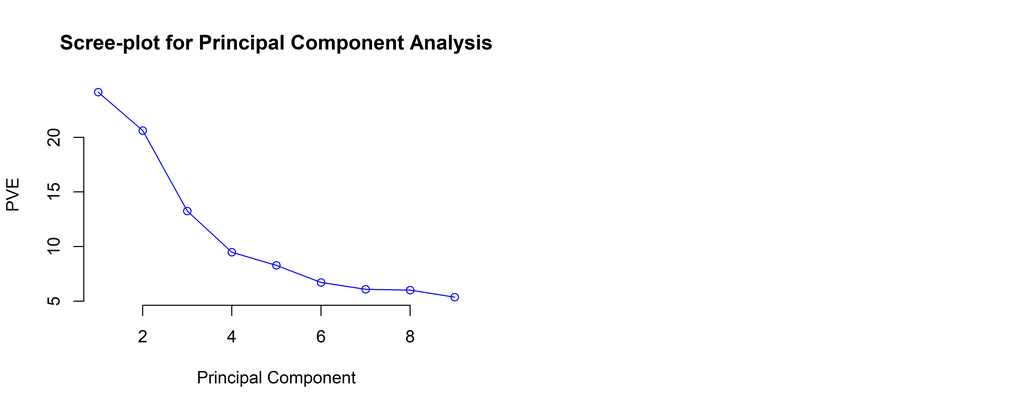

Alternatively, look at the number of Principal Components to attaint using Parallel Analysis.

Parallel Analysis: specify how many components to retain using simulation

Here, we get the critical values for each component. If the eigenvalues from the PCA are greater than the value at 0.95 confint, we can retain given component.

[output not shown]

```
## Principal Components Analysis
## Call: psych::principal(r = ., nfactors = 4, rotate = "varimax")
## Standardized loadings (pattern matrix) based upon correlation matrix
##                            RC2   RC1   RC4   RC3   h2    u2 com
## delta_diff               -0.76  0.03  0.08  0.10 0.60 0.405 1.1
## beta_diff                 0.79  0.03  0.04 -0.09 0.63 0.369 1.0
## beta_0_diff               0.79 -0.07  0.07  0.12 0.65 0.346 1.1
## dictator_diff             0.03  0.19  0.82 -0.06 0.71 0.286 1.1
## dictator_schoolmate_diff  0.00  0.11  0.85 -0.01 0.73 0.268 1.0
## risk_diff                -0.06  0.07 -0.08  0.96 0.94 0.061 1.0
## publicgood_diff           0.01  0.84 -0.06  0.03 0.70 0.297 1.0
## trust_diff               -0.06  0.71  0.28  0.26 0.65 0.351 1.6
## trust_return_diff        -0.03  0.61  0.27 -0.12 0.46 0.543 1.5
##
##                        RC2  RC1  RC4  RC3
## SS loadings           1.84 1.63 1.57 1.04
## Proportion Var        0.20 0.18 0.17 0.12
## Cumulative Var        0.20 0.38 0.56 0.67
## Proportion Explained  0.30 0.27 0.26 0.17
## Cumulative Proportion 0.30 0.57 0.83 1.00
##
## Mean item complexity =  1.2
## Test of the hypothesis that 4 components are sufficient.
##
## The root mean square of the residuals (RMSR) is  0.1
##  with the empirical chi square  707.93  with prob <  1.2e-149
##
## Fit based upon off diagonal values = 0.78
```

Overall, no clear indication on the number of components; still, in order to make it comparable with the non-demeaned data, I calculate with 4 factors in the PCA.

### 3 Factor PCA

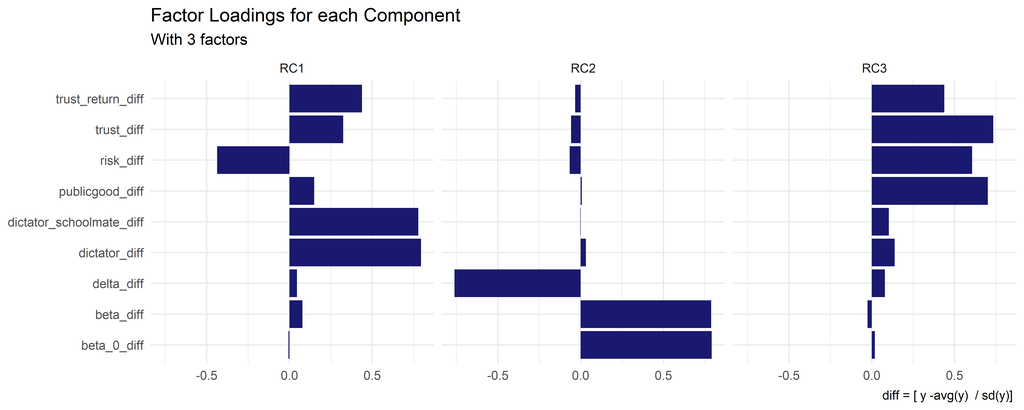

#### 4 Factor PCA

```
##
## Loadings:
##                          RC2    RC1    RC4    RC3
## delta_diff               -0.760
## beta_diff                 0.788
## beta_0_diff               0.793                0.121
## dictator_diff                    0.189  0.821
## dictator_schoolmate_diff         0.110  0.848
## risk_diff                                      0.962
## publicgood_diff                  0.836
## trust_diff                       0.706  0.282  0.261
## trust_return_diff                0.610  0.266 -0.117
##
##                  RC2   RC1   RC4   RC3
## SS loadings    1.836 1.627 1.567 1.045
## Proportion Var 0.204 0.181 0.174 0.116
## Cumulative Var 0.204 0.385 0.559 0.675
```

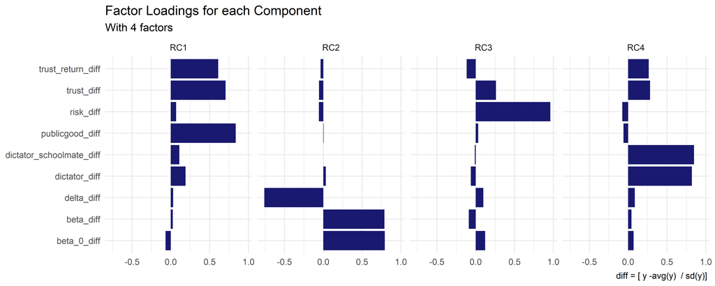

Bottom line: demeaned megmaradtak ugyanazok az eredmények.

Az ÖSSZES további Random Forest illesztésben a “math” változóra illesztettem a fákat. Lehet még olyat is illeszteni, ahol pl. top 15% percentilisre lövünk.

Random forest math változóra; PCA változók nélkül

[figure not shown]

[figure not shown]

# K-means clustering: [ Egyelőre ez az egyetlen, amit megcsináltam erre ]

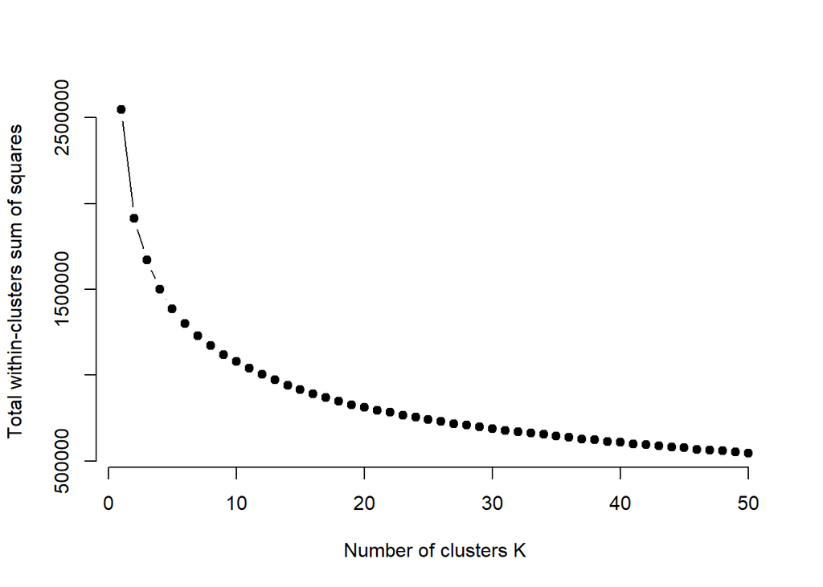

Now knowing that the number of factors is the same, I run the K-means clustering algorithm for 5 clusters:

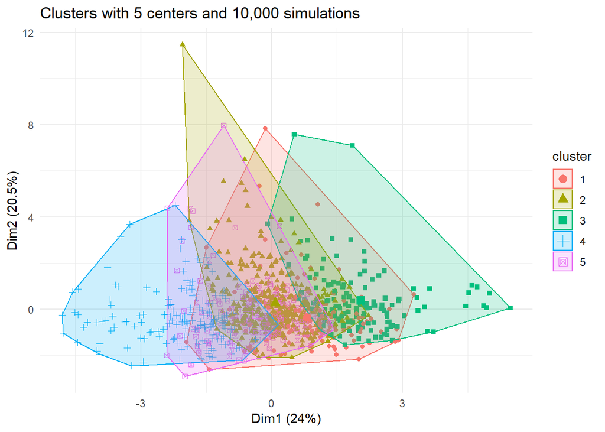